# hw-03

You You ( S2486129 )

2023-11-23

## Data Load

```r
gss16<-read.csv("data/gss16.csv")
```

## Data preparation before modelling

The `gss16` data set needs to be prepared prior to modelling. This is not an assessed component to your assignment, but it is an important part of the data science process. Carefully copy the following code into the beginning of your `.Rmd` file and ensure that you understand how the data has been prepared.

### Cleaning and selecting rows

Create a new data frame called `gss16_advfront` that includes the variables `advfront`, `emailhr` (Number of hours spent on email weekly), `educ` (education level), `polviews` (political views) and `wrkstat` (working status). Remove any row that contains any `NA`s using the `drop_na()` command

```r
gss16_advfront <- gss16 %>%
  select(advfront, emailhr, educ, polviews, wrkstat) %>%
  drop_na()
```

### Re-levelling `advfront`

The `advfront` variable contains responses to the question “Even if it brings no immediate benefits, scientific research that advances the frontiers of knowledge is necessary and should be supported by the federal government.” The possible answers are on the 5-point Likert scale: `"Strongly agree"`, `"Agree"`, `"Dont know"`, `"Disagree"` and `"Strongly disagree"`. For the purpose of this assignment, the `advfront` variable needs to be transformed such that it has two levels:

- `"Agree"` - combining the options `"Strongly agree"` and `"Agree"`.
- `"Not agree"` - combining the options `"Dont know"`, `"Disagree"` and `"Strongly disagree"`.

The following code does that this re-levelling:

```r
gss16_advfront <- gss16_advfront %>%
  mutate(
    advfront = case_when(
      advfront == "Strongly agree" ~ "Agree",
      advfront == "Agree" ~ "Agree",
      TRUE ~ "Not agree"
    ),
    advfront = fct_relevel(advfront, "Not agree", "Agree")
  )
```

### Re-levelling `polviews`

[output not shown]

The `polviews` variable contains information about the participant’s political position within 7 categories ranging from `"Extremely liberal"` to `"Extrmly conservative"`. Here we wish to simplify the range of options to 3 categories - `"Conservative"` , `"Moderate"`, and `"Liberal"`. This is achieved via the following code:

```r
gss16_advfront <- gss16_advfront %>%
  mutate(
    polviews = case_when(
      str_detect(polviews, "[Cc]onservative") ~ "Conservative",
      str_detect(polviews, "[Ll]iberal") ~ "Liberal",
      TRUE ~ polviews
    ),
    polviews = fct_relevel(polviews, "Conservative", "Moderate", "Liberal")
  )
```

Please see [chapter 14 of R for Data Science](https://r4ds.had.co.nz/strings.html) for more on string processing commands.

You now have the cleaned and pre-processe data to use for modelling, you can continue with the `gss16_advfront` for the following questions.

## Exercise 1: Create a linear regression model

Consider the numerical values `educ` and `emailhr` from your new data set `gss16_advfront`.

1. Fit a linear regression model to predicting `emailhr` based on the `educ`. From your output, state the formula for the line-of-best fit and give an interpretation of the `emailhr` estimate.
2. Comment on the overall performance of the linear regression model. Support your statements with an appropriate data visualisation and model fit statistics.

```r
# part (a.)

model_emailhr_educ <- lm(emailhr ~ educ, data = gss16_advfront)

summary(model_emailhr_educ)
```

```
##
## Call:
## lm(formula = emailhr ~ educ, data = gss16_advfront)
##
## Residuals:
##     Min      1Q  Median      3Q     Max
## -10.951  -5.838  -4.097   1.532  83.162
##
## Coefficients:
##             Estimate Std. Error t value Pr(>|t|)
## (Intercept)  -2.7573     1.6600  -1.661    0.097 .
## educ          0.6854     0.1157   5.924 4.13e-09 ***
## ---
## Signif. codes:  0 '***' 0.001 '**' 0.01 '*' 0.05 '.' 0.1 ' ' 1
##
## Residual standard error: 10.86 on 1170 degrees of freedom
## Multiple R-squared:  0.02912,    Adjusted R-squared:  0.02829
## F-statistic: 35.09 on 1 and 1170 DF,  p-value: 4.131e-09
```

```r
# part (b.)

glance(model_emailhr_educ)
```

```
## # A tibble: 1 × 12
##   r.squared adj.r.squared sigma statistic       p.value    df logLik   AIC   BIC
##       <dbl>         <dbl> <dbl>     <dbl>         <dbl> <dbl>  <dbl> <dbl> <dbl>
## 1    0.0291        0.0283  10.9      35.1 0.00000000413     1 -4458. 8922. 8937.
## # ℹ 3 more variables: deviance <dbl>, df.residual <int>, nobs <int>
```

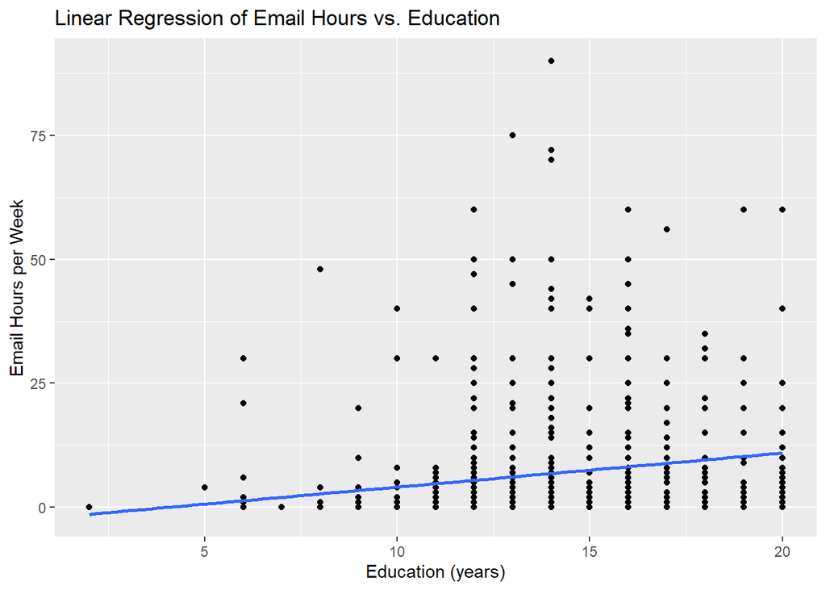

```r
ggplot(gss16_advfront, aes(x = educ, y = emailhr)) +
  geom_point() +
  geom_smooth(method = "lm", se = FALSE) +
  labs(title = "Linear Regression of Email Hours vs. Education",
       x = "Education (years)",
       y = "Email Hours per Week")
```

## Exercise 2: Create a workflow to fit a model

In this part, we’re going to build a model to predict whether someone agrees or doesn’t agree with the following statement:

Even if it brings no immediate benefits, scientific research that advances the frontiers of knowledge is necessary and should be supported by the federal government.

The responses to the question on the GSS about this statement are in the `advfront` variable, in the `gss16_advfront` data that you obtained.

First, use the following code to split the dataset into a training dataset (`gss16_train`) and a testing dataset (`gss16_test`). This code splits the data into 75% training and 25% testing.

```r
set.seed(1234)
gss16_split <- initial_split(gss16_advfront)
gss16_train <- training(gss16_split)
gss16_test  <- testing(gss16_split)
```

1. Build a workflow for the training data that consists of a recipe (`gss16_rec_1`) and a model (`gss16_mod_1`). Name this workflow `gss16_wflow_1`.

The recipe (named `gss16_rec_1`) should contain the following steps for predicting `advfront` from `educ`:

- `step_dummy()` to create dummy variables for `all_nominal()` variables that are predictors, i.e. not “outcomes”. You can select outcomes using `all_outcomes()`
- The model (named `gss16_mod_1`) should specify a model that is appropriate for the data as well as the computational engine.

```r
gss16_rec_1 <- recipe(advfront ~ educ, data = gss16_train) %>%
  step_dummy(all_nominal(), -all_outcomes())

gss16_mod_1 <- logistic_reg() %>%
  set_engine("glm")

gss16_wflow_1 <- workflow() %>%
  add_recipe(gss16_rec_1) %>%
  add_model(gss16_mod_1)
```

2. Explain why you have chosen the model that you have selected.

# I chose logistic regression because it is suitable for predicting yes/no outcomes.

## Exercise 3: Logistic regression with single predictor

1. Apply the workflow you defined earlier to the training dataset and named the model as `gss16_fit_1`. Display the resulting tibble containing the fitted model parameters.

```r
gss16_fit_1 <- gss16_wflow_1 %>%
  fit(data = gss16_train)

tidy(gss16_fit_1)
```

```
## # A tibble: 2 × 5
##   term        estimate std.error statistic   p.value
##   <chr>          <dbl>     <dbl>     <dbl>     <dbl>
## 1 (Intercept)   -0.375    0.485     -0.773 0.439
## 2 educ           0.150    0.0356     4.21  0.0000252
```

2. Use the fitted models to predict the test data, plot the ROC curves for the predictions.

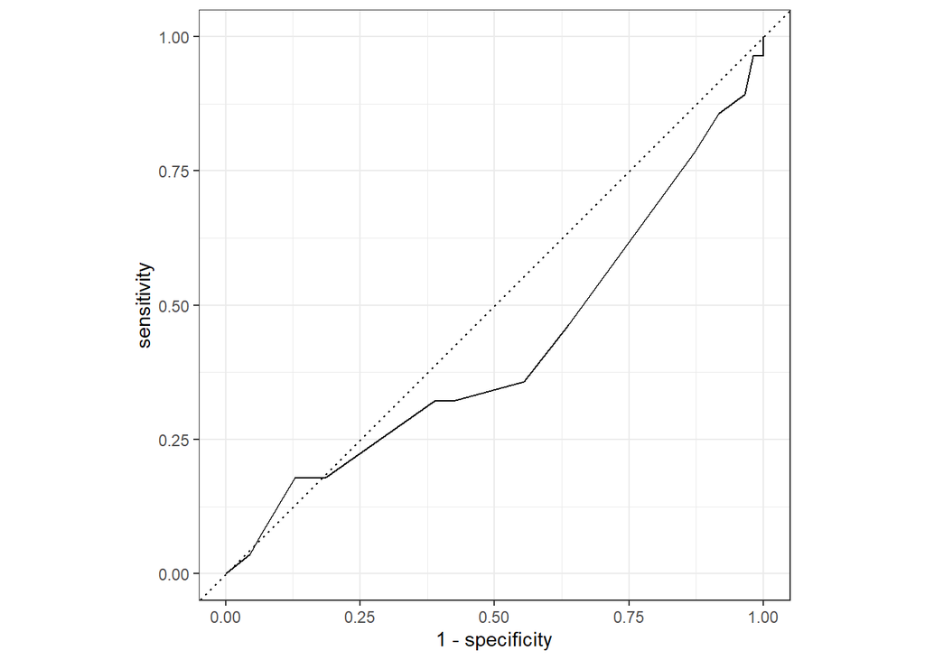

```r
gss16_preds <- predict(gss16_fit_1, new_data = gss16_test, type = "prob") %>%
  bind_cols(gss16_test)

gss16_roc_curve <- roc_curve(gss16_preds, truth = advfront, .pred_Agree)

autoplot(gss16_roc_curve)
```

## Exercise 4: Logistic regression modelling and interpretation

We are now going to model `advfront` using the explanatory variables `polviews`, `wrkstat`, and `educ`.

1. Build a new workflow for the training data that consists of a recipe (`gss16_rec_2`) and a model (`gss16_mod_2`). Name this workflow `gss16_wflow_2`. You can simply **copy, paste and edit** the code from earlier.

Now the new recipe (named `gss16_rec_2`) should contain the followings for predicting `advfront` from `polviews`, `wrkstat`, and `educ`:

- `step_dummy()` to create dummy variables for `all_nominal()` variables that are predictors, i.e. not “outcomes”. You can select outcomes using `all_outcomes()`
- The model (named `gss16_mod_2`) should specify a model that is appropriate for the data as well as the computational engine.

Apply the new workflow to the training dataset and create a new model fit named as `gss16_fit_2`.

Then use the fitted models to predict the test data, plot the ROC curve for the predictions for both models, and calculate the areas under the ROC curves.

2. Comment on which model performs better
- the model only including `educ`, as model 1 (`gss16_fit_1`)
- the model including `polviews`, `wrkstat`, and `educ` with `gss16_split` as model 2 (`gss16_fit_2`)

Explain your reasoning.